# ━━━━━━━━━━━━━━━━━━━━━━━━━━━━━━━━━━━━━━━━━━━━━━━━━━━━━━━━━ تمرین اول Computer Vission ━━━━━━━━━━━━━━━━━━━━━━━━━━━━━━━━━━━━━━━━━━━━━━━━━━━━━━━━━

## بخش دوم

مشخصات دانشجویان:

نام و نام خانوادگی: نیلوفر مرتضوی

شماره دانشجویی: 220701096

نام و نام خانوادگی: برنا فروهری

شماره دانشجویی: 810101480

زیربخش اول  
تصویر را دوباره بارگذاری نمایید.

```python
import cv2
import numpy as np
import matplotlib.pyplot as plt
```

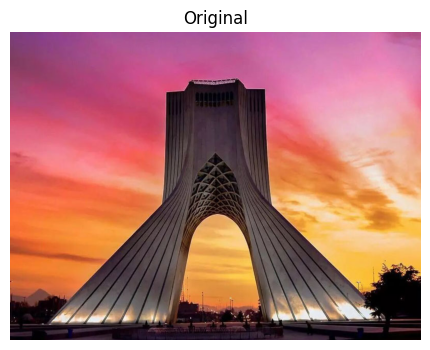

```python
def show(title, img):
    plt.figure(figsize=(6,4))
    if len(img.shape) == 2:
        plt.imshow(img, cmap='gray')
    else:
        plt.imshow(cv2.cvtColor(img, cv2.COLOR_BGR2RGB))
    plt.title(title)
    plt.axis('off')
    plt.show()

img = cv2.imread("Pic.jpg")
show("Original", img)
```

زیربخش دوم  
یکی از نویزهای متداول در پردازش تصویر، نویز فلفل و نمک (Salt and Pepper Noise) است. این نویز را به تصویر اضافه کرده و نتیجه‌ی حاصل را نمایش دهید. همچنین، درباره‌ی یکی دیگر از انواع نویزهای رایج در پردازش تصویر، توضیحی کوتاه ارائه نمایید.

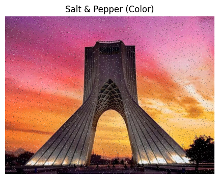

```python
def add_salt_pepper_noise_color(image, amount=0.03, s_vs_p=0.5):
    noisy = image.copy()
    H, W, C = noisy.shape
    num_pixels = H * W

    num_salt = int(num_pixels * amount * s_vs_p)
    num_pepper = int(num_pixels * amount * (1 - s_vs_p))

    # salt
    coords = (np.random.randint(0, H, num_salt),
              np.random.randint(0, W, num_salt))
    noisy[coords[0], coords[1], :] = 255

    # pepper
    coords = (np.random.randint(0, H, num_pepper),
              np.random.randint(0, W, num_pepper))
    noisy[coords[0], coords[1], :] = 0

    return noisy

sp_color = add_salt_pepper_noise_color(img, amount=0.03)
show("Salt & Pepper (Color)", sp_color)
```

**پاسخ تشریحی زیربخش دوم:**  
نویز فلفل‌نمکی یکی از پرکاربردترین مدل‌های نویز ضربه‌ای در پردازش تصویر است. این نویز به صورت ایجاد تعدادی پیکسل کاملاً سفید (Salt) یا کاملاً سیاه (Pepper) در نقاط تصادفی تصویر ظاهر می‌شود. علت اصلی وقوع این نویز می‌تواند وجود خطا در حسگرهای دوربین، نویزهای ناگهانی در انتقال داده و یا نقص در تجهیزات دیجیتال باشد. این نویز به دلیل آن که تنها بخشی از پیکسل‌ها را با اختلاف شدید مقدار روشنایی دچار مشکل می‌کند، می‌تواند ظاهر تصویر را به شدت مختل کند.  
نویز گوسی (Gaussian Noise) یکی از رایج‌ترین مدل‌های نویز افزایشی در پردازش تصویر است. مقدار این نویز در هر پیکسل از یک توزیع نرمال با میانگین و انحراف معیار مشخص نمونه‌برداری می‌شود. این نویز معمولاً در مراحل دریافت تصویر توسط حسگر دوربین، به دلیل نوسانات حرارتی و الکترونیکی ایجاد می‌شود. بر خلاف نویز فلفل‌نمکی که تنها برخی پیکسل‌ها را به مقدار ۰ یا ۲۵۵ تبدیل می‌کند، نویز گوسی تمامی پیکسل‌ها را تحت تأثیر قرار می‌دهد و باعث ایجاد تغییرات کوچک و پیوسته در شدت روشنایی می‌شود. در نتیجه حذف این نویز نیازمند فیلترهایی است که کل تصویر را به‌صورت یکنواخت نرم کنند، مانند فیلتر گوسی یا میانگین‌گیر. با این حال، فیلتر بیش‌ازحد می‌تواند باعث کاهش جزئیات و محو شدن لبه‌های تصویر شود.

زیربخش سوم  
مفهوم کرنل (Kernel) در پردازش تصویر را تعریف کرده، کاربردهای آن را بیان نمایید و نحوه‌ی اعمال کرنل بر روی تصویر را توضیح دهید.

**پاسخ تشریحی زیربخش سوم:**  
کرنل یا ماسک یک ماتریس کوچک (معمولاً ۳×۳ یا ۵×۵) است که برای ایجاد تغییرات محلی روی تصویر به کار می‌رود. هدف از اعمال کرنل این است که مقدار پیکسل جدید در نقطه‌ی مورد نظر، بر اساس ترکیبی از همان پیکسل و همسایه‌هایش به دست آید. فرآیند اعمال کرنل به تصویر، کانولوشن (Convolution) نام دارد. در این روش، کرنل روی تصویر حرکت داده می‌شود و برای هر موقعیت، حاصل ضرب‌داخلی عناصر کرنل با پیکسل‌های ناحیه‌ی متناظر محاسبه و سپس جمع می‌شود. نتیجه‌ی این محاسبه مقدار پیکسل خروجی را می‌سازد. استفاده از کرنل کاربردهای مختلفی دارد، از جمله: حذف نویز، شارپ‌ سازی، آشکارسازی لبه‌ها، تشخیص بافت‌ها.

زیربخش چهارم  
بر روی تصویر اصلی، فیلتر میانگین (Mean Filter)، فیلتر گوسی (Gaussian Filter) و فیلتر میانه (Median Filter) را اعمال کنید و درباره‌ی هر یک از آن‌ها، توضیح مختصری شامل نوع کرنل و نمونه‌ای از آن ارائه دهید.

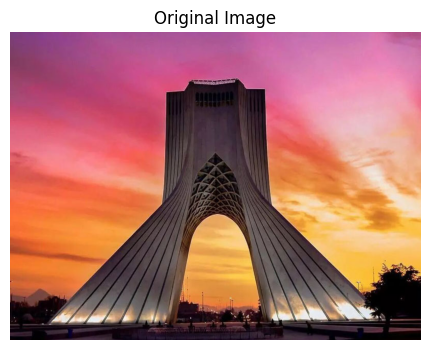

[figure not shown]

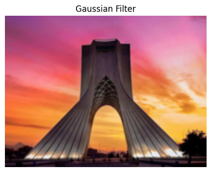

[figure not shown]

```python
import cv2
import numpy as np
import matplotlib.pyplot as plt

def show(title, img):
    plt.figure(figsize=(6,4))
    plt.imshow(cv2.cvtColor(img, cv2.COLOR_BGR2RGB))
    plt.title(title)
    plt.axis('off')
    plt.show()

def manual_convolution(img, kernel):
    b, g, r = cv2.split(img)
    h, w = b.shape
    kh, kw = kernel.shape
    pad_h, pad_w = kh // 2, kw // 2

    def apply_single_channel(channel):
        padded = np.pad(channel, ((pad_h, pad_h), (pad_w, pad_w)), mode='reflect')
        output = np.zeros_like(channel, dtype=np.float32)
        for i in range(h):
            for j in range(w):
                region = padded[i:i+kh, j:j+kw]
                output[i, j] = np.sum(region * kernel)
        return np.clip(output, 0, 255).astype(np.uint8)

    b_f = apply_single_channel(b)
    g_f = apply_single_channel(g)
    r_f = apply_single_channel(r)
    return cv2.merge((b_f, g_f, r_f))

def manual_median(img, ksize=15):
    b, g, r = cv2.split(img)
    h, w = b.shape
    pad = ksize // 2

    def apply_single_channel(channel):
        padded = np.pad(channel, pad, mode='reflect')
        output = np.zeros_like(channel)
        for i in range(h):
            for j in range(w):
                region = padded[i:i+ksize, j:j+ksize]
                output[i, j] = np.median(region)
        return output

    b_f = apply_single_channel(b)
    g_f = apply_single_channel(g)
    r_f = apply_single_channel(r)
    return cv2.merge((b_f, g_f, r_f))

def make_gaussian_kernel(size=15, sigma=2):
    ax = np.arange(-size//2 + 1., size//2 + 1.)
    xx, yy = np.meshgrid(ax, ax)
    kernel = np.exp(-(xx**2 + yy**2) / (2. * sigma**2))
    kernel /= np.sum(kernel)
    return kernel

img = cv2.imread("Pic.jpg")
show("Original Image", img)

#mean
mean_kernel = np.ones((15,15), np.float32) / (15*15)
mean_filtered = manual_convolution(img, mean_kernel)
show("Mean Filter", mean_filtered)

#gaussian
gaussian_kernel = make_gaussian_kernel(size=15, sigma=2)
gaussian_filtered = manual_convolution(img, gaussian_kernel)
show("Gaussian Filter", gaussian_filtered)

#median
median_filtered = manual_median(img, 15)
show("Median Filter", median_filtered)
```

**پاسخ تشریحی زیربخش چهارم:**  
در این بخش سه فیلتر پرکاربرد میانگین، گوسی و میانه به‌صورت دستی پیاده‌سازی و بر روی تصویر اصلی اعمال شده‌اند. هدف این فیلترها حذف نویز و صاف‌تر کردن تصویر است. برخلاف نسخه‌های آماده در OpenCV، در اینجا عملیات کانولوشن (convolution) به صورت دستی با استفاده از حلقه‌ها و کرنل‌ها انجام گرفته است.  
**۱) فیلتر میانگین (Mean Filter):**  
این فیلتر مقدار هر پیکسل را با میانگین مقادیر همسایگی جایگزین می‌کند. کرنل آن از مقادیر مساوی تشکیل شده است. این فیلتر باعث کاهش نویز می‌شود اما لبه‌های تصویر را نیز تا حدی محو می‌کند.  
نمونه کرنل ۳×۳:

```
1/9 * [[1, 1, 1],

       [1, 1, 1],

       [1, 1, 1]]
```

**۲) فیلتر گوسی (Gaussian Filter):**  
در این فیلتر پیکسل‌های نزدیک‌تر به مرکز کرنل وزن بیشتری دارند. در نتیجه خروجی نرم‌تر و طبیعی‌تر است. این فیلتر معمولاً برای حذف نویزهای تصادفی (مانند نویز سنسور) استفاده می‌شود.  
نمونه کرنل ۳×۳ گوسی:

```
1/16 * [[1, 2, 1],

        [2, 4, 2],

        [1, 2, 1]]
```

**۳) فیلتر میانه (Median Filter):**  
این فیلتر مقدار هر پیکسل را با میانه‌ی مقادیر همسایگی جایگزین می‌کند. مزیت اصلی آن حذف نویزهای ضربه‌ای مانند نویز فلفل‌نمکی است، بدون اینکه لبه‌های تصویر به شدت محو شوند.  
در پیاده‌سازی دستی این فیلترها، ابتدا کرنل‌ها به‌صورت ماتریس تعریف شده‌اند و سپس با پیمایش پیکسل‌ها و ضرب داخلی کرنل و ناحیه‌ی متناظر، مقدار جدید هر پیکسل محاسبه شده است. برای فیلتر میانه نیز همسایگی مرتب و مقدار میانه انتخاب می‌شود. نتایج نشان می‌دهند که تصویر خروجی نرم‌تر شده و نویزهای جزئی کاهش یافته‌اند.

زیربخش پنجم  
مشخص کنید کدام‌یک از فیلترهای فوق برای حذف نویز مناسب‌تر است. سپس، آن فیلتر را بر روی تصویری که نویز فلفل و نمک به آن افزوده‌اید اعمال نموده و نتایج حاصل را تحلیل و توضیح دهید.

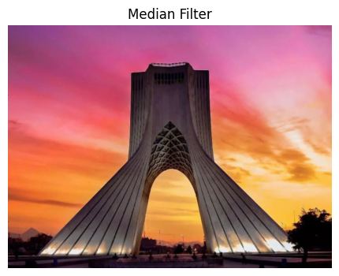

```python
median_color = manual_median(sp_color, 3)
show("Median Filter", median_color)
```

**پاسخ تشریحی زیربخش پنجم:** در نویز فلفل‌نمکی، تعداد محدودی از پیکسل‌ها مقدار بسیار متفاوت (۰ یا ۲۵۵) به خود می‌گیرند. در این نوع نویز، پیکسل‌های خراب‌شده به صورت نقطه‌های کاملاً سیاه و سفید دیده می‌شوند. فیلترهای میانگین و گوسی به‌جای حذف این نقاط پرت، آن‌ها را در همسایگی پخش کرده و باعث ایجاد هاله و محو شدن لبه‌ها می‌شوند.

در مقابل، فیلتر میانه مقدار پیکسل مرکزی را با میانهٔ همسایگی جایگزین کرده و پیکسل‌های پرت را حذف می‌کند. در نتیجه، هم نویز از بین می‌رود و هم لبه‌ها و جزئیات تصویر تا حد زیادی حفظ می‌شوند.

بنابراین، بهترین فیلتر برای حذف نویز فلفل‌نمکی، فیلتر میانه (Median Filter) است.

نتایج بصری نیز نشان می‌دهد که تصویر خروجی فیلتر میانه وضوح و کیفیت بالاتری دارد و نقاط سفید و سیاه اضافی تقریباً به‌طور کامل حذف شده‌اند

زیربخش ششم  
بر روی تصویر اصلی، فیلتر لبه‌یابی (Canny) و همچنین فیلترهای سوبل (Sobel) و لاپلاسین (Laplacian) را اعمال کرده و نتایج حاصل را نمایش دهید. همچنین درباره هر یک از آن‌ها توضیح مختصری شامل نوع کرنل و نمونه‌ای از آن ارائه نمایید.

[figure not shown]

[figure not shown]

[figure not shown]

```python
sobel_x = np.array([
    [-1, 0, 1],
    [-2, 0, 2],
    [-1, 0, 1]
], np.float32)

sobel_y = np.array([
    [-1, -2, -1],
    [0, 0, 0],
    [1, 2, 1]
], np.float32)

sobel_x_img = manual_convolution(img, sobel_x)
sobel_y_img = manual_convolution(img, sobel_y)
sobel_combined = np.sqrt(sobel_x_img.astype(np.float32)**2 + sobel_y_img.astype(np.float32)**2)
sobel_combined = np.clip(sobel_combined, 0, 255).astype(np.uint8)
show("Manual Sobel Edge", sobel_combined)


laplacian_kernel = np.array([
    [0, -1, 0],
    [-1, 4, -1],
    [0, -1, 0]
], np.float32)

laplacian_manual = manual_convolution(img, laplacian_kernel)
show("Manual Laplacian Edge", laplacian_manual)


gaussian_kernel = np.array([
    [1, 2, 1],
    [2, 4, 2],
    [1, 2, 1]
], np.float32) / 16.0
blurred = manual_convolution(img, gaussian_kernel)


gx = manual_convolution(blurred, sobel_x)
gy = manual_convolution(blurred, sobel_y)
mag = np.sqrt(gx.astype(np.float32)**2 + gy.astype(np.float32)**2)
edges = (mag > 100).astype(np.uint8) * 255
show("Manual Canny", edges)
```

[figure not shown]

[figure not shown]

[figure not shown]

```python
sobelx = cv2.Sobel(img, cv2.CV_64F, 1, 0, ksize=3)
sobely = cv2.Sobel(img, cv2.CV_64F, 0, 1, ksize=3)

sobel = cv2.convertScaleAbs(cv2.magnitude(sobelx, sobely))
show("Sobel Edge Detection", sobel)

lap = cv2.Laplacian(img, cv2.CV_64F, ksize=3)
lap = cv2.convertScaleAbs(lap)
show("Laplacian Edge Detection", lap)


canny = cv2.Canny(img, 100, 200)
show("Canny Edge Detection", canny)
```

**پاسخ تشریحی زیربخش ششم:**  
در پردازش تصویر، لبه‌ها نواحی‌ای هستند که شدت روشنایی به‌طور ناگهانی تغییر می‌کند. به همین دلیل، روش‌های لبه‌یابی از مشتق‌گیری برای شناسایی این نقاط استفاده می‌کنند. در این بخش سه روش متداول لبه‌یابی شامل سوبل، لاپلاسین و کنی بر روی تصویر اصلی اعمال شده‌اند.  
**۱) فیلتر سوبل (Sobel)**  
این فیلتر با محاسبه مشتق مرتبه اول در دو جهت افقی و عمودی، لبه‌ها را شناسایی می‌کند. سوبل توانایی تشخیص جهت لبه‌ها را دارد، اما نسبت به نویز کمی حساس‌تر است و معمولاً خروجی آن شامل لبه‌ها به همراه مقدار کمی نویز است.  
**۲) فیلتر لاپلاسین (Laplacian)**  
این فیلتر از مشتق مرتبه دوم استفاده می‌کند و نواحی‌ای را که تغییر روشنایی شدیدی دارند شناسایی می‌کند. خروجی لاپلاسین شامل لبه‌های زیادی است اما به نویز بسیار حساس‌تر می‌باشد و معمولاً لبه‌های اضافی نمایش داده می‌شوند.  
**۳) الگوریتم کِنی (Canny)**  
کنی یک روش چندمرحله‌ای بسیار دقیق است. در ابتدا نویز با فیلتر گوسی کاهش داده می‌شود، سپس گرادیان محاسبه شده و در مرحلهٔ نازک‌سازی، فقط لبه‌های واقعی حفظ می‌شوند. در نهایت با آستانه‌گذاری هوشمند، لبه‌های ضعیف حذف و لبه‌های مهم نگه داشته می‌شوند. این روش تمیزترین و دقیق‌ترین لبه‌ها را ارائه می‌دهد.  
**نتیجه‌گیری:**  
خروجی سوبل و لاپلاسین شامل لبه‌های بیشتری همراه با نویز هستند، در حالی که فیلتر کنی لبه‌های دقیق، نازک و تفکیک‌شده‌تری ارائه می‌دهد. بنابراین روش کنی بهترین عملکرد را در لبه‌یابی تصویر اصلی دارد.